# Final Project: New York City Stop-Question-Frisk Analysis Part I: Individual Analysis

Xingyao Chen Section 5

**Purpose:**

This project will give you the opportunity to apply the techniques learned in Math 35 to a *real* and *sizeable* data set. Moreover, you will use these techniques to draw conclusions about the efficacy of a controversial crime policy: the stop-question-frisk (SQF), also known as stop-and-frisk, program, in New York City.

For this first part of the project, you will work *individually* to familiarize yourselves with the data. This portion of the project is due **Tuesday, December 6, in class.**

**Background:**

In stop-question-frisk, a police officer is authorized to stop a pedestrian, question them, and then frisk their body searching for contraband items such as weapons or drugs. The motivation for the policy was to prevent crimes from happening in the first place, though recent studies by the New York Civil Liberties Union suggest the policy did not achieve noticeable reductions in crime. For example, NYCLU estimates that guns were found in fewer than 0.2% of stops. Moreover, the policy was found to be discriminatory because Blacks and Latinos were stopped disproportionately more than their participation in crime would suggest. (Since 2014, new restrictions have limited the use of SQF, and the numbers of SQF incidents have decreased precipitously.)

Data from New York City’s stop-question-frisk (SQF) program is publicly available online. Whenever a person is stopped under SQF, the officer is required to fill out a form with information about the stop. Each year, the data is compiled and released by the city. Since the data from the form has over 100 columns, we will be giving you a version of the data that has been simplified to 22 of the most interesting fields. Every SQF stop from 2010 and 2015 is still represented in the data. If you are interested, you can find the full data set at: http://www.nyc.gov/html/nypd/html/analysis_and_planning/stop_question_and_frisk_report.shtml. However, for this project, please **only use the version of the SQF data that has been provided for the course**.

2. **Mandatory Classroom Attendance - Tuesday/Thursday December 6/8 - 10% of Grade**

You will complete the project in groups of four, which will be determined on Tuesday, December 6. Class time on Tuesday, December 6 and Thursday, December 8 will be allocated for you to work with your group. Therefore, **attendance on these days will be mandatory and count as 10% of your project grade**.

3. **Team Report - Due Tuesday December 13 by 5 PM - 50% of Grade**

Working in teams of four, write a report that presents your statistical analysis in response to the set of required questions given here (20%), and in response to a set of questions that interests you as a team (30%). Use appropriate graphical and statistical methods to justify your responses to the questions. Please refer to the section on Project Evaluation Criteria below for information on how to structure your report.

**Required Questions - 20% of Grade**

The purpose of these problems is to remind you of and to assess your ability to use the main statistical tools that we have discussed in Math 35. You will be asked to use these tools while exploring different parts of the SQF data.

1. Because all of the data provided are reported by the police officers who stopped the suspects, it is possible that there is misreported data. For example, an officer may misidentify an Asian/Pacific Islander as Hispanic, or vice-versa. We would like to explore what effect such misidentifications can have on the collected data. To simplify our analysis, we will only consider the subset of the data for which suspects were identified as Asian/Pacific Island or Hispanic. Suppose that a Hispanic person has a 95% chance of correctly being identified as Hispanic, and otherwise is misidentified as Asian/Pacific Islander, and an Asian/Pacific Islander has a 95% chance of correctly being identified as Asian/Pacific Islander, and otherwise is misidentified as Hispanic. Using this subset of the 2010 data, determine the probability that a stopped suspect is Hispanic and the probability that a stopped suspect is Asian/Pacific Islander. Use this to determine the probability that someone who is identified by the officer as Hispanic is actually Hispanic and the probability that someone who is identified as Asian/Pacific Islander is actually Asian/Pacific Islander. What does this say about how we utilize the `race` column of the data?

```r
sqf2010=read.csv("2010_sqf_m35.csv")
sqf2015=read.csv("2015_sqf_m35.csv")

sqf2010_as=sqf2010[c(sqf2010$race=="ASIAN/PACIFIC ISLANDER"),]
sqf2010_wh=sqf2010[c(sqf2010$race=="WHITE-HISPANIC"),]
sqf2010_bh=sqf2010[c(sqf2010$race=="BLACK-HISPANIC"),]

sqf2010_sub=rbind(sqf2010_as,sqf2010_wh , sqf2010_bh)
races=sqf2010_sub$race

LH=(38377+149532)/length(races)
LA=(19630)/length(races)
```

LH=suspect is labled as Hispanic

LA=suspect is labled as Asian

A=suspect is Asian

H=suspect is Hispanic

$$\begin{align*}
P(LH)&=P(LH|H)P(H)+P(LH|A)P(A)\\
P(LA)&=P(LA|H)P(H)+P(LA|A)P(A)\\
0.9&=0.95P(H)+0.05P(A)\\
0.09&=0.05P(H)+0.95*P(A)\\
P(H)=0.95067\\
P(A)=0.04933
\end{align*}$$
The conditional probabiliies
$$\begin{align*}
P(H|LH)&=\frac{P(LH|H)P(H)}{P(LH)}\\
P(A|LA)&=\frac{P(LA|A)P(A)}{P(LA)}\\
P(H|LH)&=0.997\\
P(A|LA)&=0.4964\\
\end{align*}$$

2. Compare the rates at which suspects stopped in 2010 were frisked, broken down by race. Are the differences in rates between the various groups statistically significant? Which borough(s) had the largest differences? The smallest?

**Solution**

```r
#split the frisked data by race
splittedByRace=split(sqf2010$frisked, sqf2010$race)
#forloop to find all the p-values
results=data.frame()
for (i in 1:length(splittedByRace)){
  for(j in 1:length(splittedByRace)){
    var1=names(splittedByRace)[i]
    var2=names(splittedByRace)[j]
    pval=t.test(splittedByRace[[i]], splittedByRace[[j]])$p.value
    row=data.frame(var1, var2, pval)
    results=rbind(results, row)
  }
}

#find the groups with the largest differences
results[results$pval==min(results$pval),]
```

```
##              var1           var2 pval
## 23          BLACK          WHITE    0
## 31 BLACK-HISPANIC          WHITE    0
## 51          WHITE          BLACK    0
## 52          WHITE BLACK-HISPANIC    0
## 56          WHITE WHITE-HISPANIC    0
## 63 WHITE-HISPANIC          WHITE    0
```

```r
#find the groups with the smalled differences (top 60% of pvals excluding identical co)
results_sub=results[results$pval<1,]
results_sub[results_sub$pval>0.4*max(results_sub$pval),]
```

```
##                              var1                           var2      pval
## 2  AMERICAN INDIAN/ALASKAN NATIVE         ASIAN/PACIFIC ISLANDER 0.4618376
## 9          ASIAN/PACIFIC ISLANDER AMERICAN INDIAN/ALASKAN NATIVE 0.4618376
## 47                        UNKNOWN                          WHITE 0.2230251
## 54                          WHITE                        UNKNOWN 0.2230251
```

The largest difference is between WHITE and WHITE-HISPANIC, WHITE vs BLACK, and WHITE vs BLACK-HISPANIC. The smallest difference is AMERICAN INDIAN/ALASKAN NATIVE vs ASIAN/PACIFIC ISLANDER, and UNKNOWN vs WHITE.

```r
#split the frisked data by city
splittedByCity=split(sqf2010$frisked, sqf2010$city)
#forloop to find all the p-values
results=data.frame()
for (i in 1:length(splittedByCity)){
  for(j in 1:length(splittedByCity)){
    var1=names(splittedByCity)[i]
    var2=names(splittedByCity)[j]
    pval=t.test(splittedByCity[[i]], splittedByCity[[j]])$p.value
    row=data.frame(var1, var2, pval)
    results=rbind(results, row)
  }
}

#find the groups with the largest differences
results[results$pval==min(results$pval),]
```

```
##         var1      var2 pval
## 9      BRONX  BROOKLYN    0
## 10     BRONX MANHATTAN    0
## 12     BRONX STATEN IS    0
## 14  BROOKLYN     BRONX    0
## 17  BROOKLYN    QUEENS    0
## 20 MANHATTAN     BRONX    0
## 23 MANHATTAN    QUEENS    0
## 27    QUEENS  BROOKLYN    0
## 28    QUEENS MANHATTAN    0
## 30    QUEENS STATEN IS    0
## 32 STATEN IS     BRONX    0
## 35 STATEN IS    QUEENS    0
```

```r
#find the groups with the smalled differences (top 60% of pvals excluding identical co)
results_sub=results[results$pval<1,]
results_sub[results_sub$pval>0.4*max(results_sub$pval),]
```

```
##         var1      var2      pval
## 3             BROOKLYN 0.7979995
## 4            MANHATTAN 0.7924557
## 6            STATEN IS 0.5704495
## 13  BROOKLYN           0.7979995
## 16  BROOKLYN MANHATTAN 0.7958508
## 19 MANHATTAN           0.7924557
## 21 MANHATTAN  BROOKLYN 0.7958508
## 31 STATEN IS           0.5704495
```

The largest difference is between BRONX and BROOKLYN, BRONX and BROOKLYN, BRONX and MANHATTAN, BRONX and STATEN IS, BROOKLYN and QUEENS, MANHATTAN and QUEENS, and QUEENS and STATEN IS.

The smallest difference is between BROOKLYN and MANHATTAN, UNKNOW and BROOKLYN, and UNKNOW and STATEN IS, UNKNOW and MANHATTAN.

3. Compare the distribution of ages for male suspects in 2010 with the distribution of ages for female suspects in 2010. Use `qqnorm` to determine if they are normally distributed, and compare them with each other by using `qqplot`. Are the age distributions the same? Compare the age distribution for male suspects to that of the entire population of suspects that were stopped in 2010. Type `?qqplot` for help on how to use the command. Note that some ages are reported as 0 or 999 if the officer did not know the age, so you may want to throw out the extraneous data first.

**Solution**

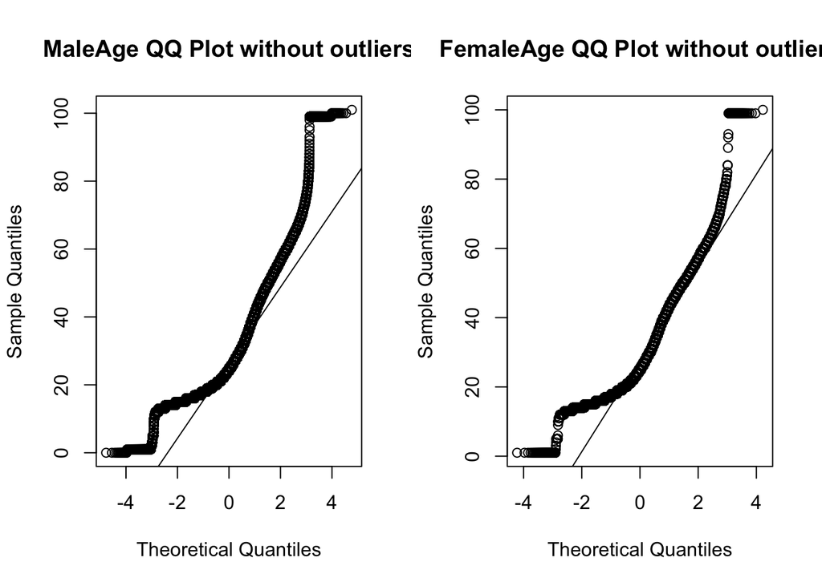

```r
#throw out outliers
AllAge <- sqf2010[sqf2010$age <110,]

#subset F and M
MaleAge <- AllAge$age[AllAge$sex == "M"]
FemaleAge <- AllAge$age[AllAge$sex == "F"]

par(mfrow=c(1,2))
#qqnorm plots for normality
qqnorm(MaleAge, main = "MaleAge QQ Plot without outliers")
qqline(MaleAge)
qqnorm(FemaleAge, main = "FemaleAge QQ Plot without outliers")
qqline(FemaleAge)
```

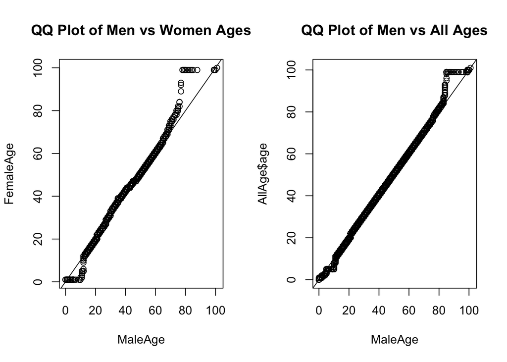

```r
qqplot(MaleAge,FemaleAge, main = "QQ Plot of Men vs Women Ages")
abline(0,1)

qqplot(MaleAge,AllAge$age , main= "QQ Plot of Men vs All Ages")
abline(0,1)
```

The distributions between Females and Males are approximately the same, because the `qqplot` results yielded points that fall pretty closely on the $y=x$ line.

4. Find the probability, with a 95% confidence interval, that a suspect was frisked (a) for the entire population in 2015, and (b) for suspects in 2015 who refused to provide identification, and determine whether suspects who refused to provide identification had a different probability of being frisked than the population at large.

```r
frisked=sqf2015$frisked
mu=mean(frisked)
SEM=1.96*sd(frisked)/sqrt(length(frisked))
mu;SEM
```

```
## [1] 0.6761955
```

```
## [1] 0.006105832
```

1. The probability, with a 95% confidence interval, that a suspect was frisked for the entire population in 2015 is 0.6761955 $\pm$ 0.0061058.

```r
frisked_id=frisked[sqf2015$typeofid=="REFUSED"]
mu1=mean(frisked_id)
SEM1=1.96*sd(frisked_id)/sqrt(length(frisked_id))
mu1;SEM1
```

```
## [1] 0.6103286
```

```
## [1] 0.03784224
```

2. The probability, with a 95% confidence interval, that a suspect who refused to provide ID was frisked is 0.6103286 $\pm$ 0.0378422.

A two sample t-test can be used to determine whether these rates significantly differ.

```r
t.test(x = sqf2015$frisked, y = sqf2015$frisked[sqf2015$typeofid == "REFUSED"], conf.level = 0.95)
```

```
##
##  Welch Two Sample t-test
##
## data:  sqf2015$frisked and sqf2015$frisked[sqf2015$typeofid == "REFUSED"]
## t = 3.368, df = 671.64, p-value = 0.0008005
## alternative hypothesis: true difference in means is not equal to 0
## 95 percent confidence interval:
##  0.02746674 0.10426706
## sample estimates:
## mean of x mean of y
## 0.6761955 0.6103286
```

The t-test suggests there is a significant difference in the probability a suspect in general will be frisked vs. the probability a suspect who refuses to provide ID will be frisked (p < .05).

22. For the 2010 data, decide which of the following binary factors: `arstmade`, `searched`, `inside`, `sumissue`, `frisked`, `weap`, `contrabn` `radio`, `pf` had a significant effect on the length of the stop (`perstop`) by using linear regression. Make sure to check your residuals for normality, and apply an appropriate transformation to `perstop` or remove outlier points if it does not look normal (see your notes from Lecture 11 to review how to do this). Note that `perstop` is a discrete variable, so you are looking for an approximately normal distribution for the residuals. Consider the p-values for the coefficients and the $R^2$ value for your regression model. What do they indicate about how the factors affect the length of the stop? Recall that $R^2 = \frac{SSR}{SST}$. How much of the variability in `perstop` is due to the explanatory variables you have selected? Why does this make sense?

```r
sqf2010=sqf2010[sqf2010$perstop<60,]

lmdata=sqf2010[, c("arstmade", "searched", "inside", "sumissue", "frisked", "weap",
                   "contrabn", "radio", "pf")]
mod=list()
lmout=data.frame()
for (i in names(lmdata)){
  mod[[i]]=summary(lm(sqf2010$perstop~as.factor(lmdata[,i])))
  row=data.frame(i, mod[[i]]$r.squared)
  lmout=rbind(lmout, row)
}
lmout
```

```
##          i mod..i...r.squared
## 1 arstmade       0.0109950884
## 2 searched       0.0116435327
## 3   inside       0.0005851448
## 4 sumissue       0.0142917592
## 5  frisked       0.0034338813
## 6     weap       0.0010134042
## 7 contrabn       0.0021368759
## 8    radio       0.0192165505
## 9       pf       0.0071013775
```

To answer this question, it is useful to understand how to interpret a regression model involving indicator variables. Suppose you have an indicator variable $X$ that equals 1 when a condition is true and 0 otherwise, and you fit the following regression model:
$$Y = \beta_0 + \beta_1 X + \epsilon$$
Note that when $X=0$, meaning that the condition is false, $Y = \beta_0 + \epsilon$, and when $X=1$, meaning that the condition is true, $Y = \beta_0 + \beta_1 + \epsilon$. Therefore, $\beta_1$, the coefficient on $X$ in the regression model, gives the *average effect* that the condition has on the outcome. That is $\beta_1$ equals the mean difference in the response when the condition is true compared to when it is false. Our hypothesis is constructed in the same way as always: $H_0: \beta_1=0$ is the null hypothesis asserting that the condition has no effect on $Y$. $H_a: \beta_1 \neq 0$ is the alternative hypothesis asserting that the condition has some effect on $Y$. If the p-value on $\beta_1$ after we fit the regression model is smaller than our significance level $\alpha$, then we reject $H_0$ and conclude that the condition being true has a statistically significant effect on the value of $Y$.

**Team-Chosen Questions - 30% of Grade**

In the second part of your report, your team will investigate questions about the data that are interesting to you as a team and of some broader importance to the assessment of SQF policies. As reiterated below in the section on Project Evaluation Criteria, you are expected to formulate clear questions that are addressable within the data set, and provide answers to those questions that are substantiated by appropriate graphical and statistical analysis.

To help you get started, here are some questions you might consider exploring:

- Read through the NYCLU report referenced below. Choose a set of claims and verify if they are substantiated in your data set. Also explain any assumptions you need to make in order for the claims to be substantiated, and assess whether they are reasonable assumptions. Some examples of claims you could examine include: The NYCLU stated that fewer than 0.2% of stops led to confiscation of a weapon. They also stated that Blacks and Latinos were stopped disproportionately more often than other races, even relative to their participation in crime (as victims or perpetrators). (You might need to find, and cite, other crime statistics or demographic data to help conduct your analysis.)
- Read through articles by proponents of SQF (such as the National Review op-ed referenced below). Choose a set of claims and verify if they are substantiated in your data set. Also explain any assumptions you need to make in order for the claims to be substantiated, and assess whether they are reasonable assumptions. An example of a claim you could examine is that the policy helps minorities because they are most likely to be living in high-crime neighborhoods and themselves be victims of violent crimes. (You might need to find, and cite, other crime statistics or demographic data to help conduct your analysis.)
- Examine SQF rates by borough. Compare those rates to demographic data available from the US Census Bureau. Are people stopped in proportion to the demographic characteristics of the area? Are they frisked in proportion to the demographic characteristics of the area?

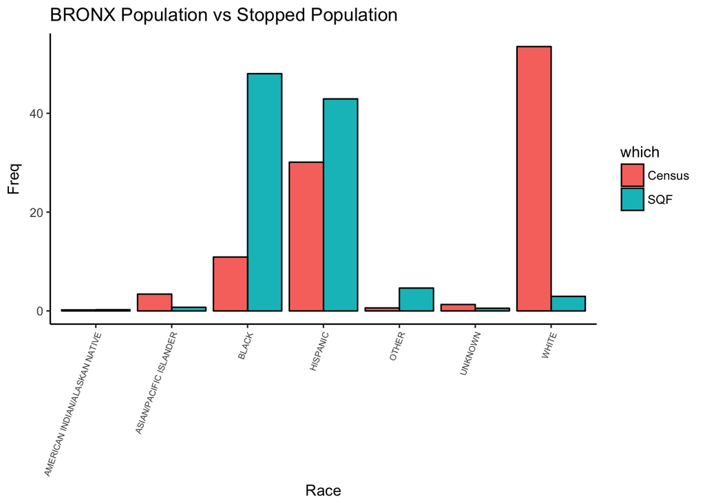

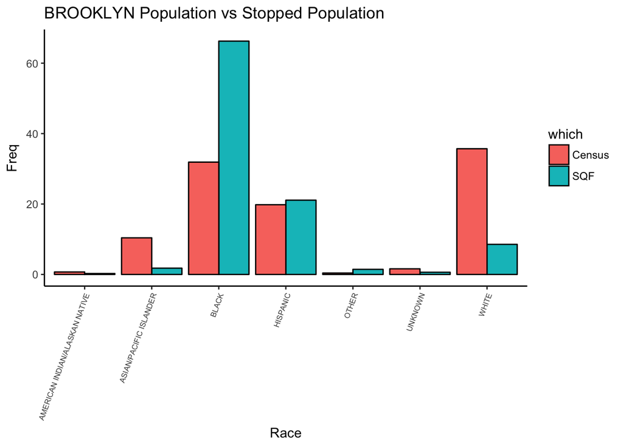

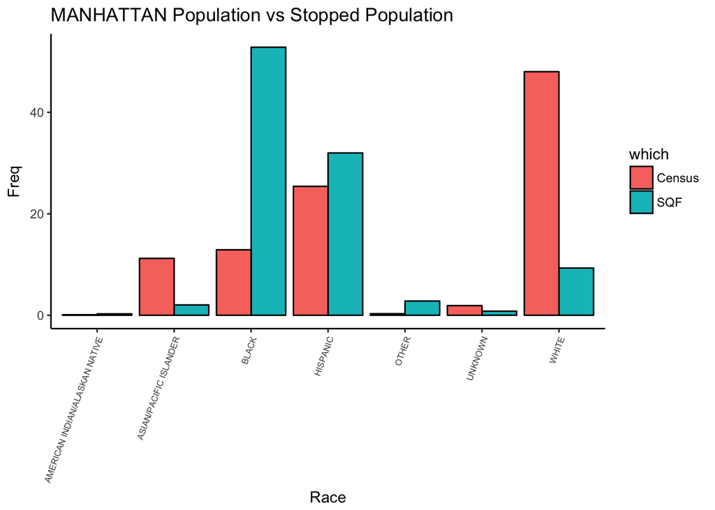

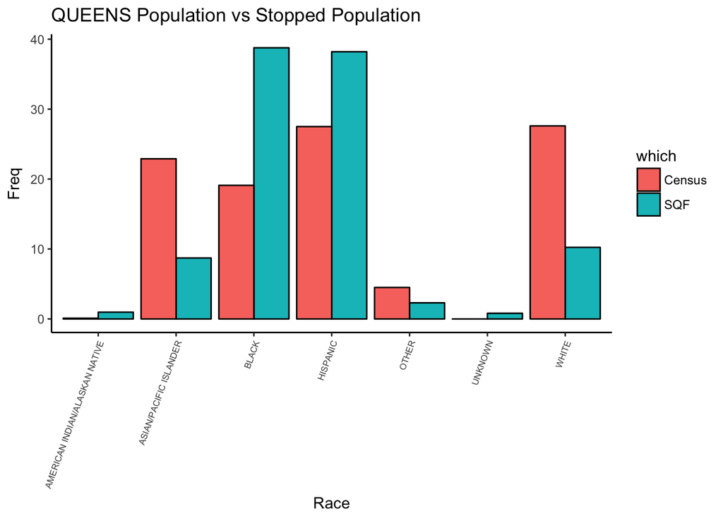

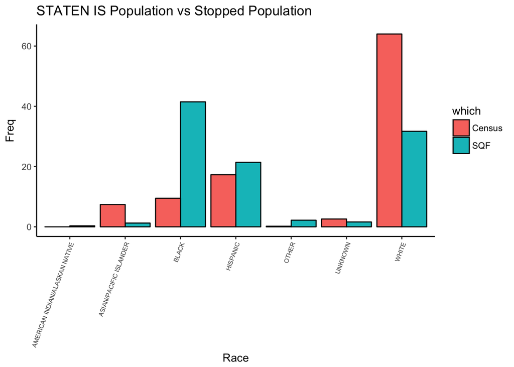

```r
sqf2010$race=gsub("BLACK-","",sqf2010$race)
sqf2010$race=gsub("WHITE-","",sqf2010$race)
sqf2010_by_borough=split(sqf2010, sqf2010$city)
races=unique(sqf2010$race)

count=table(sqf2010_by_borough$BRONX$race)
sqfBronx=100*count/sum(count)
sqfBronx=data.frame(sqfBronx)
sqfBronx$which="SQF"
names(sqfBronx)[1]="Race"

count=table(sqf2010_by_borough$BROOKLYN$race)
sqfBrooklyn=100*count/sum(count)
sqfBrooklyn=data.frame(sqfBrooklyn)
sqfBrooklyn$which="SQF"
names(sqfBrooklyn)[1]="Race"

count=table(sqf2010_by_borough$MANHATTAN$race)
sqfMan=100*count/sum(count)
sqfMan=data.frame(sqfMan)
sqfMan$which="SQF"
names(sqfMan)[1]="Race"

count=table(sqf2010_by_borough$QUEENS$race)
sqfQueens=100*count/sum(count)
sqfQueens=data.frame(sqfQueens)
sqfQueens$which="SQF"
names(sqfQueens)[1]="Race"

count=table(sqf2010_by_borough$`STATEN IS`$race)
sqfStanten=100*count/sum(count)
sqfStanten=data.frame(sqfStanten)
sqfStanten$which="SQF"
names(sqfStanten)[1]="Race"



bronx=c(10.9,30.1, 53.5, 0.6, 3.4,  1.3,0.2)
bronxData=data.frame(Race=races, Freq=bronx, which="Census")

staten=c(9.5, 17.3, 64.0, 0.2, 7.4, 2.6 ,0)
statenData=data.frame(Race=races, Freq=staten, which="Census")

queens=c(19.1, 27.5, 27.6, 4.5, 22.9, 0, 0.1)
queensData=data.frame(Race=races, Freq=queens, which="Census")

man=c(12.9, 25.4, 48.0, 0.3, 11.2, 1.9, 0.1)
manData=data.frame(Race=races, Freq=man, which="Census")


brook=c(31.9, 19.8, 35.7, 0.4, 10.4, 1.6, 0.7)
brookData=data.frame(Race=races, Freq=brook, which="Census")

sqf_vs_staten=rbind(sqfStanten, statenData)
sqf_vs_bronx=rbind(sqfBronx, bronxData)
sqf_vs_queens=rbind(sqfQueens, queensData)
sqf_vs_man=rbind(sqfMan, manData)
sqf_vs_brook=rbind(sqfBrooklyn, brookData)


bigL=list(Bronx=sqf_vs_bronx,Brooklyn=sqf_vs_brook,Manhattan=sqf_vs_man, Queens=sqf_vs_queens,StatenIsle=sqf_vs_staten)
cities=names(sqf2010_by_borough)[-1]
c=1
for (i in bigL){
  city=cities[c]
  p=ggplot(i, aes(x=Race, y=Freq, fill=which))+
    geom_bar(stat="identity", position=position_dodge(), color="Black")+
    theme_classic()+
    theme(axis.text.x = element_text(angle = 70, hjust = 1, size = rel(0.7) ))+
    ggtitle(paste(city,"Population vs Stopped Population"))
  plot(p)
  c=c+1
  }
```

After plotting 5 comparison bar plots for each of the 5 boroughs in New York City, there is a clear trend that we noticed. The percentage of stops per race was plotted adjacently to the race percentage in a particular borough. We found that the percentage of stops in each borough for both African Americans and Hispanics, exceeded the percentage of the population African Americans and Hispanics that lived in that borough. However, out of the total number of people that were stopped, the percentage that were white was much smaller than the percentage of white people in that particular borough. This could mean that police officers are more likely to stop an African American or Hispanic person rather than a white person, even though there may be more white people that live in the borough than African Americans or Hispanics. This is clearly a problem in the New York City area and is likely one of the reasons why African Americans and Hispanics have been upset with the nation’s police departments.

We can use `prop.test` to test for the significance of the difference.

```r
pop_staten=c(nrow(sqf2010_by_borough$`STATEN IS`), 468730)
pop_bronx=c(nrow(sqf2010_by_borough$BRONX),1385108)
pop_man=c(nrow(sqf2010_by_borough$MANHATTAN),1585873)
pop_queen=c(nrow(sqf2010_by_borough$QUEENS),223072)
pop_brook=c(nrow(sqf2010_by_borough$BROOKLYN),2504710)
pop_vectors=rbind(pop_bronx,pop_brook, pop_man, pop_queen , pop_staten)

pData_black=data.frame()
for(i in 1:length(bigL)){
  city_data=bigL[[i]]
  blk=city_data[city_data$Race=="BLACK",][,2]*pop_vectors[i,]/100
  table=cbind(blk, pop_vectors[i,])
  rownames(table)=c("SQF", "Census")
  pval=prop.test(table, alternative="greater",correct=F)
  pval=pval$p.value
  pData_black=rbind(pData_black, data.frame(city=cities[i], pval=pval))
}



pData_his=data.frame()
for(i in 1:length(bigL)){
  city_data=bigL[[i]]
  blk=city_data[city_data$Race=="HISPANIC",][,2]*pop_vectors[i,]/100
  table=cbind(blk, pop_vectors[i,])
  rownames(table)=c("SQF", "Census")
  pval=prop.test(table, alternative="greater",correct=F)
  pval=pval$p.value
  pData_his=rbind(pData_his, data.frame(city=cities[i], pval=pval))
}


pData_white=data.frame()
for(i in 1:length(bigL)){
  city_data=bigL[[i]]
  blk=city_data[city_data$Race=="WHITE",][,2]*pop_vectors[i,]/100
  table=cbind(blk, pop_vectors[i,])
  rownames(table)=c("SQF", "Census")
  pval=prop.test(table, alternative="less", correct=F)
  pval=pval$p.value
  pData_white=rbind(pData_white, data.frame(city=cities[i], pval=pval))
}

#hypothesis test to test whether the the proportion of stopped who are black is greater than the proportion of blacks in the population, for each city
pData_black
```

```
##        city pval
## 1     BRONX    0
## 2  BROOKLYN    0
## 3 MANHATTAN    0
## 4    QUEENS    0
## 5 STATEN IS    0
```

```r
#hypothesis test to test whether the the proportion of stopped who are hispanic is greater than the proportion of hispanics in the population, for each city
pData_his
```

```
##        city         pval
## 1     BRONX 0.000000e+00
## 2  BROOKLYN 2.115799e-29
## 3 MANHATTAN 0.000000e+00
## 4    QUEENS 0.000000e+00
## 5 STATEN IS 1.869752e-47
```

```r
#hypothesis test to test whether the the proportion of stopped who are black is greater than the proportion of blacks in the population, for each city
pData_white
```

```
##        city pval
## 1     BRONX    0
## 2  BROOKLYN    0
## 3 MANHATTAN    0
## 4    QUEENS    0
## 5 STATEN IS    0
```

In order to test if the difference between the percentage of people of a certain race stopped and the percentage of people of a certain race who live in that borough are drastically different, we used the prop.test function in R. For both the black and hispanic populations we said that our alternative hyopthesis was that the percentage of stopped people who are black are greater than the percentage of black people in that borough. We found that the p-value calculated using this function gave us roughly zero for the percentage of stopped people who are black versus the percentage of black people in that borough. Since the p-value is less than 0.05 than we can confidently say that these two percentages are significantly different (which is a problem). The $H_0$ is rejected. Performing the same prop.test for the hispanic population of each other five boroughs, we get practically identical results, all the p-values are practically 0 (which is less than 0.05) so we can confidently say that these two percentages are significantly different for hispanics as well. As for the white population, we said the alternative hypothesis was that the percentage of stopped people who are white is less than the perentage of white people in that borough. The p-values we got for each of the five boroughs was approximately 0, rejecting our $H_0$. This means that we can say that the percentage of white people in the borough is significantly greater than the percentage of stopped people that are white.

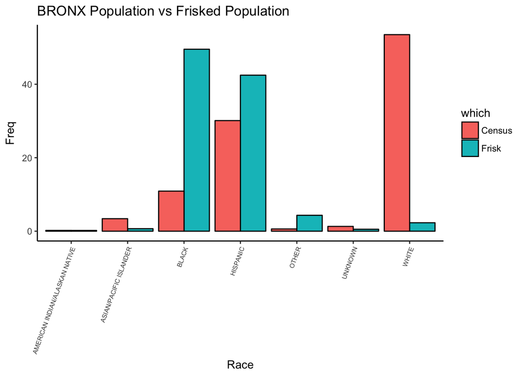

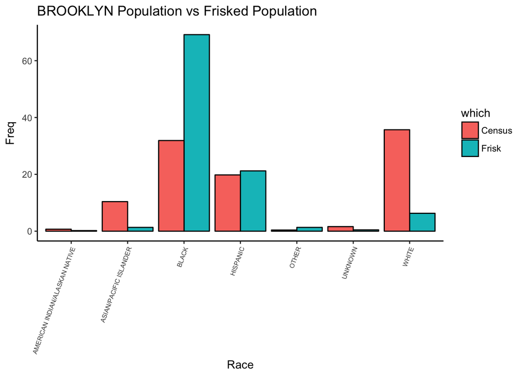

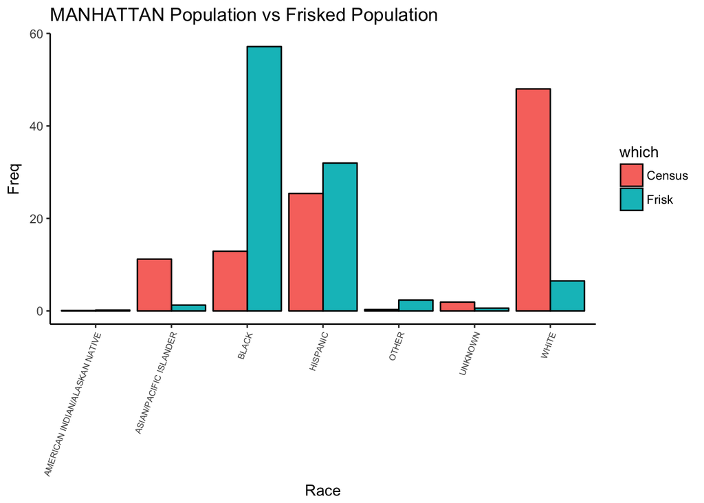

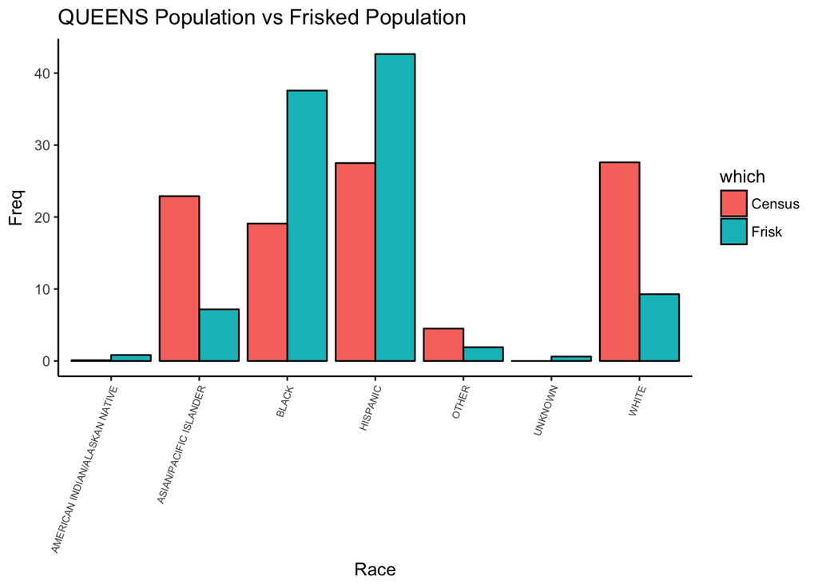

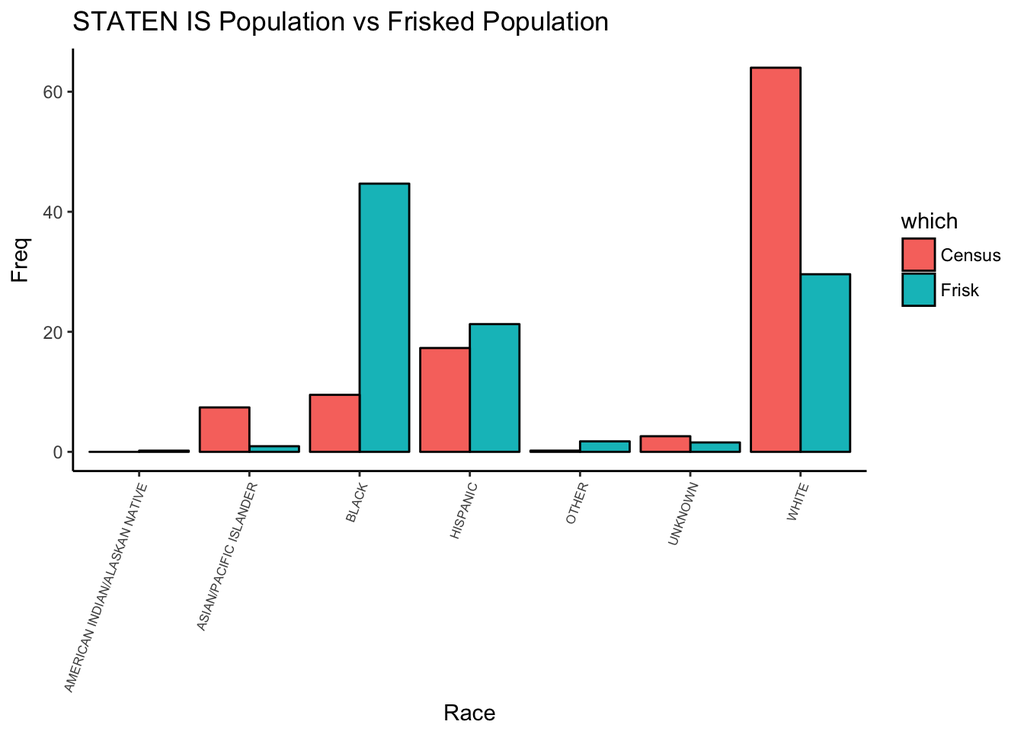

```r
Freq <- (table(sqf2010$race[sqf2010$frisked & sqf2010$city == "BRONX"])*100/sum(sqf2010$frisked[sqf2010$city == "BRONX"]))
friskData <- data.frame(Freq)
friskData$which <- "Frisk"
names(friskData)=names(bronxData)
frisk_vs_bronx=rbind(friskData, bronxData)

Freq <- (table(sqf2010$race[sqf2010$frisked & sqf2010$city == "STATEN IS"])*100/sum(sqf2010$frisked[sqf2010$city == "STATEN IS"]))
friskData <- data.frame(Freq)
friskData$which <- "Frisk"
names(friskData)=names(bronxData)
frisk_vs_staten=rbind(friskData, statenData)

Freq <- (table(sqf2010$race[sqf2010$frisked & sqf2010$city == "QUEENS"])*100/sum(sqf2010$frisked[sqf2010$city == "QUEENS"]))
friskData <- data.frame(Freq)
friskData$which <- "Frisk"
names(friskData)=names(bronxData)
frisk_vs_queens=rbind(friskData, queensData)

Freq <- (table(sqf2010$race[sqf2010$frisked & sqf2010$city == "MANHATTAN"])*100/sum(sqf2010$frisked[sqf2010$city == "MANHATTAN"]))
friskData <- data.frame(Freq)
friskData$which <- "Frisk"
names(friskData)=names(bronxData)
frisk_vs_man=rbind(friskData, manData)

Freq <- (table(sqf2010$race[sqf2010$frisked & sqf2010$city == "BROOKLYN"])*100/sum(sqf2010$frisked[sqf2010$city == "BROOKLYN"]))
friskData <- data.frame(Freq)
friskData$which <- "Frisk"
names(friskData)=names(bronxData)
frisk_vs_brook=rbind(friskData, brookData)


bigL=list(Bronx=frisk_vs_bronx,Brooklyn=frisk_vs_brook,Manhattan=frisk_vs_man, Queens=frisk_vs_queens,StatenIsle=frisk_vs_staten)
cites=names(sqf2010_by_borough)[-1]
c=1
for (i in bigL){
  city=cites[c]
  p=ggplot(i, aes(x=Race, y=Freq, fill=which))+
    geom_bar(stat="identity", position=position_dodge(), color="Black")+
    theme_classic()+
    theme(axis.text.x = element_text(angle = 70, hjust = 1, size = rel(0.7) ))+
    ggtitle(paste(city,"Population vs Frisked Population"))
  plot(p)
  c=c+1
}
```

We can use `prop.test` to test for the significance of the difference.

```r
pop_staten=c(nrow(sqf2010_by_borough$`STATEN IS`), 468730)
pop_bronx=c(nrow(sqf2010_by_borough$BRONX),1385108)
pop_man=c(nrow(sqf2010_by_borough$MANHATTAN),1585873)
pop_queen=c(nrow(sqf2010_by_borough$QUEENS),223072)
pop_brook=c(nrow(sqf2010_by_borough$BROOKLYN),2504710)
pop_vectors=rbind(pop_bronx,pop_brook, pop_man, pop_queen , pop_staten)

pData_black=data.frame()
for(i in 1:length(bigL)){
  city_data=bigL[[i]]
  blk=city_data[city_data$Race=="BLACK",][,2]*pop_vectors[i,]/100
  table=cbind(blk, pop_vectors[i,])
  rownames(table)=c("SQF", "Census")
  pval=prop.test(table, alternative="greater",correct=F)
  pval=pval$p.value
  pData_black=rbind(pData_black, data.frame(city=cities[i], pval=pval))
}



pData_his=data.frame()
for(i in 1:length(bigL)){
  city_data=bigL[[i]]
  blk=city_data[city_data$Race=="HISPANIC",][,2]*pop_vectors[i,]/100
  table=cbind(blk, pop_vectors[i,])
  rownames(table)=c("SQF", "Census")
  pval=prop.test(table, alternative="greater",correct=F)
  pval=pval$p.value
  pData_his=rbind(pData_his, data.frame(city=cities[i], pval=pval))
}


pData_white=data.frame()
for(i in 1:length(bigL)){
  city_data=bigL[[i]]
  blk=city_data[city_data$Race=="WHITE",][,2]*pop_vectors[i,]/100
  table=cbind(blk, pop_vectors[i,])
  rownames(table)=c("SQF", "Census")
  pval=prop.test(table, alternative="less", correct=F)
  pval=pval$p.value
  pData_white=rbind(pData_white, data.frame(city=cities[i], pval=pval))
}

#hypothesis test to test whether the the proportion of frisked who are black is greater than the proportion of blacks in the population, for each city
pData_black
```

```
##        city pval
## 1     BRONX    0
## 2  BROOKLYN    0
## 3 MANHATTAN    0
## 4    QUEENS    0
## 5 STATEN IS    0
```

```r
#hypothesis test to test whether the the proportion of frisked who are hispanic is greater than the proportion of hispanics in the population, for each city
pData_his
```

```
##        city         pval
## 1     BRONX 0.000000e+00
## 2  BROOKLYN 9.690730e-35
## 3 MANHATTAN 0.000000e+00
## 4    QUEENS 0.000000e+00
## 5 STATEN IS 2.416089e-44
```

```r
#hypothesis test to test whether the the proportion of frisked who are black is greater than the proportion of blacks in the population, for each city
pData_white
```

```
##        city pval
## 1     BRONX    0
## 2  BROOKLYN    0
## 3 MANHATTAN    0
## 4    QUEENS    0
## 5 STATEN IS    0
```

4. **Peer Evaluation - Due Tuesday December 13 by 5PM - 25% of Grade**

You will evaluate yourself and your teammates on the following axes:

- Contributions to the statistical analysis
- Contributions to the writing of the report
- Punctuality, reliability
- Respectfulness to all team members

Complete the peer evaluation form at https://goo.gl/forms/QD3Lgf1Z1j7HEDjp2 by Tuesday December 13 at 5PM.

**Project Evaluation Criteria**

Your grade will consist of the following components:

1. 15% Individual work due on Tuesday, December 6
2. 10% Attendance on Tuesday, December 6 and Thursday, December 8
3. 50% Written report
- 20% Addressing required questions
- 30% Addressing team-chosen questions
4. 25% Peer evaluation

The written report will be in the form of a paper of no more than 15 pages, including your answers to the required problems and any graphs. In addition, you will be asked to submit either an RMarkdown or .R script file containing all of the commands used for your analysis. **Please upload the file to your Sakai Drop Box in the Math 35 course website.** The file will be used to verify the output that produced your analysis, so please add enough comments to the file so that we can see which commands are relevant to each part of the analysis.

You should write your report as if you are a statistical consultant hired by the New York Police Department to respond to their questions about the SQF policy. Make clear references to figures as appropriate and offer answers to their questions in plain English. However, you may assume that the person you are writing for has knowledge of introductory probability and statistics. You should NOT submit reams of statistical output; this should be a polished report, not a problem set.

The report should have the following structure:

1. Introduction (overview in your own words of the data; summary of your team’s chosen question, why it’s important, and what you found; roadmap for the remainder of the report.)
2. Responses to required questions: Please list each question/answer separately, but write formal responses to the questions.
3. Analysis of your chosen questions: Be sure to describe your questions and why they are interesting/important, and provide suitable graphical and statistical analysis of the data to answer the questions.
4. Conclusions and Recommendations
5. Bibliography if you use any external sources
6. Appendices as necessary

Your report will be evaluated based on the following criteria:

- Writing: Structure of report; clarity of writing; quality of editing and polishing the document
- Correctness of methodology: Appropriate graphical and statistical techniques are used to answer the questions
- Validity of interpretation: The results are interpreted correctly
- Significance: The team-chosen question(s) leverage the available data to provide insight into the stop-question-frisk policy.

We encourage you to bring a draft of your report to the Writing Center for feedback.

**A Final Note**

The policy of SQF is a sensitive and charged one. Some of you (or your teammates) may have had direct experience with the policy, perhaps in connection to your (or their) race or ethnicity. A recent paper by Geller demonstrated the negative mental health impacts on those who have experienced SQF encounters. By contrast, some of you (or your teammates) might support SQF. As well-educated Mudders, all of us have a responsibility to use the analytical tools at our disposal to inform policy decisions, either through direct employment in public offices or as informed and engaged citizens/residents. As you explore this dataset, please challenge yourself to think critically about the data, and to operate in an atmosphere of respect with your teammates, classmates, and professors.

**Bibliography**

Barone, M., “Stop-and-Frisk Protects Minorities”, http://www.nationalreview.com/article/356481/stop-and-frisk-protects-minorities-michael-barone, 2013.

New York Civil Liberties Union website: http://www.nyclu.org/node/1598

New York Civil Liberties Union, “Stop and Frisk During the Bloomberg Administration”, http://www.nyclu.org/files/publications/stopandfrisk_briefer_2002-2013_final.pdf

Geller, A., Fagan, J., Tyler, T., Link, B., “Aggressive Policing and the Mental Health of Young Urban Men”, *Am J Public Health.* 2014 December; 104(12): 2321-2327. Published online 2014 December. doi: 10.2105/AJPH.2014.302046